## Why Mathmatics for Economics? What is it?

From Simon and Blume:

"If we think of a model simply as the reduction ond organization of subject matter for study, it is clear that models are not unique to mathematical analysis. Even social sciences such as sociology or anthropology, whose techniques are more "literary" than mathematical, rely heavily on models of some sort..."

"Mathematical model forces the economist to define terms precisely. THe economist must state the underling assumptions clearly before embarking on a complex train of thought.."

"Often, economsits use mathematical techniques such as logical deduction to derive theorems which apply to a wide variety of economic situations..."

"It is also needed to broaden the applicability of a model that is too narrowly constructed to be useful..."

## Beyond Graphical Analysis

We can use matlab to graph the indifference curves as contour plots

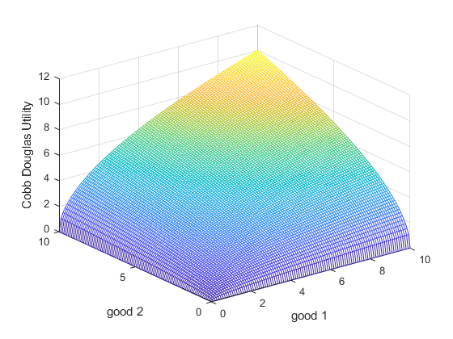

```matlab
close all;
figure();
x1 = linspace(0,10,100);
x2 = linspace(0,10,100);
[x1mesh, x2mesh] = meshgrid(x1,x2);
U = (x1mesh.^0.5).*(x2mesh.^0.5);

mesh(x1mesh,x2mesh,U)
xlabel('good 1');
ylabel('good 2');
zlabel('Cobb Douglas Utility');
```

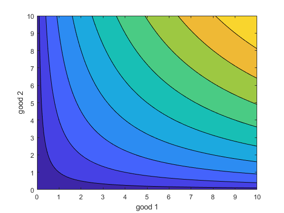

```matlab
figure();
contourf(x1mesh,x2mesh,U)
xlabel('good 1');
ylabel('good 2');
zlabel('Cobb Douglas Utility');
```